# Analysis Regression House Pricing

# 3 Exploratory Data Analysis

Exploratory data analysis is a phase where we explore the data variables, see if there are any pattern that can indicate any kind of correlation between variables.

Find the Pearson correlation between features.

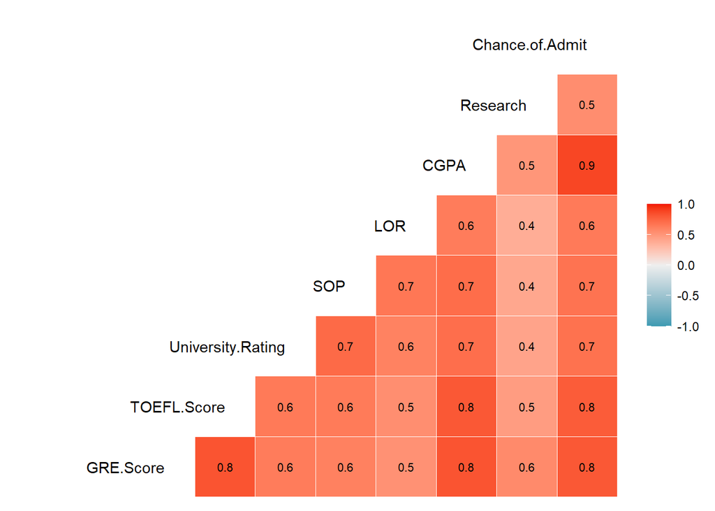

```r
ggcorr(grad, label = TRUE, label_size = 2.9, hjust = 1, layout.exp = 2)
```

The graphic shows that a lot of variable has strong correlation with the `Chance.of.Admit` variables.

# 4 Modeling

## 4.1 Holdout :Train-TestSplit

Before we make the model, we need to split the data into train dataset and test dataset. We will use the train dataset to train the linear regression model. The test dataset will be used as a comparasion and see if the model get overfit and can not predict new data that hasn’t been seen during training phase. We will 50% of the data as the training data and the rest of it as the testing data.

```r
set.seed(123)
samplesize <- round(0.5 * nrow(grad), 0)
index <- sample(seq_len(nrow(grad)), size = samplesize)

train_set <- grad[index,] # taining set
test_set <- grad[-index,]  # test set
```

Now we have training set of 250 rows and test dataset of same rows.

## 4.2 Linear Regression

Now we will try to model the linear regression using `Chance.of.Admit` as the target variable

```r
set.seed(123)
grad_lm <- lm(Chance.of.Admit ~ ., data = grad)

summary(grad_lm)
```

```
##
## Call:
## lm(formula = Chance.of.Admit ~ ., data = grad)
##
## Residuals:
##       Min        1Q    Median        3Q       Max
## -0.266657 -0.023327  0.009191  0.033714  0.156818
##
## Coefficients:
##                     Estimate Std. Error t value             Pr(>|t|)
## (Intercept)       -1.2757251  0.1042962 -12.232 < 0.0000000000000002 ***
## GRE.Score          0.0018585  0.0005023   3.700             0.000240 ***
## TOEFL.Score        0.0027780  0.0008724   3.184             0.001544 **
## University.Rating  0.0059414  0.0038019   1.563             0.118753
## SOP                0.0015861  0.0045627   0.348             0.728263
## LOR                0.0168587  0.0041379   4.074            0.0000538 ***
## CGPA               0.1183851  0.0097051  12.198 < 0.0000000000000002 ***
## Research           0.0243075  0.0066057   3.680             0.000259 ***
## ---
## Signif. codes:  0 '***' 0.001 '**' 0.01 '*' 0.05 '.' 0.1 ' ' 1
##
## Residual standard error: 0.05999 on 492 degrees of freedom
## Multiple R-squared:  0.8219, Adjusted R-squared:  0.8194
## F-statistic: 324.4 on 7 and 492 DF,  p-value: < 0.00000000000000022
```

After the preprocessing of dataset, now we can fit a linear model. To cycle through all possible combinations of predictors and generate set of best performing models, we will use the regsubset.

```r
# using regsubsets to select predictors subset, set method = exhaustive
regsubsets.out <- regsubsets(Chance.of.Admit ~ .,
                              data = grad,
                              nbest = 1,  # number of subsets of each size to record
                              nvmax = NULL,  # maximum size of subsets to examine
                              force.in = NULL, force.out = NULL,
                              method = 'exhaustive')
```

```r
# converts this to dataframe and show the choosing result
as.data.frame(summary(regsubsets.out)$outmat)
```

|  | GRE.Score | TOEFL.Score | University.Rating | SOP | LOR | CGPA | Research |
| --- | --- | --- | --- | --- | --- | --- | --- |
| 1 ( 1 ) |  |  |  |  |  | * |  |
| 2 ( 1 ) | * |  |  |  |  | * |  |
| 3 ( 1 ) | * |  |  |  | * | * |  |
| 4 ( 1 ) | * |  |  |  | * | * | * |
| 5 ( 1 ) | * | * |  |  | * | * | * |
| 6 ( 1 ) | * | * | * |  | * | * | * |
| 7 ( 1 ) | * | * | * | * | * | * | * |

Then we use Adjusted Rsq value to estimate performance of each predictors.

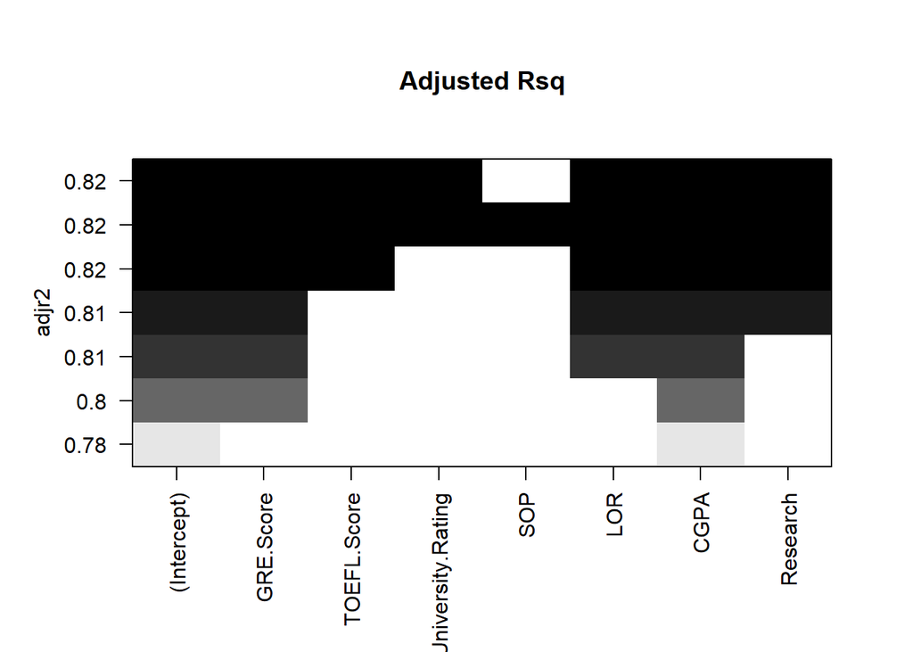

```r
# create plot of results, it includes fit performance information
plot(regsubsets.out, scale='adjr2', main='Adjusted Rsq')
```

# 5 Model Selection

Next, we should select the optimum model base on the slection results of predictors.

*1. We we build a linear model with CGPA as the single predictor*

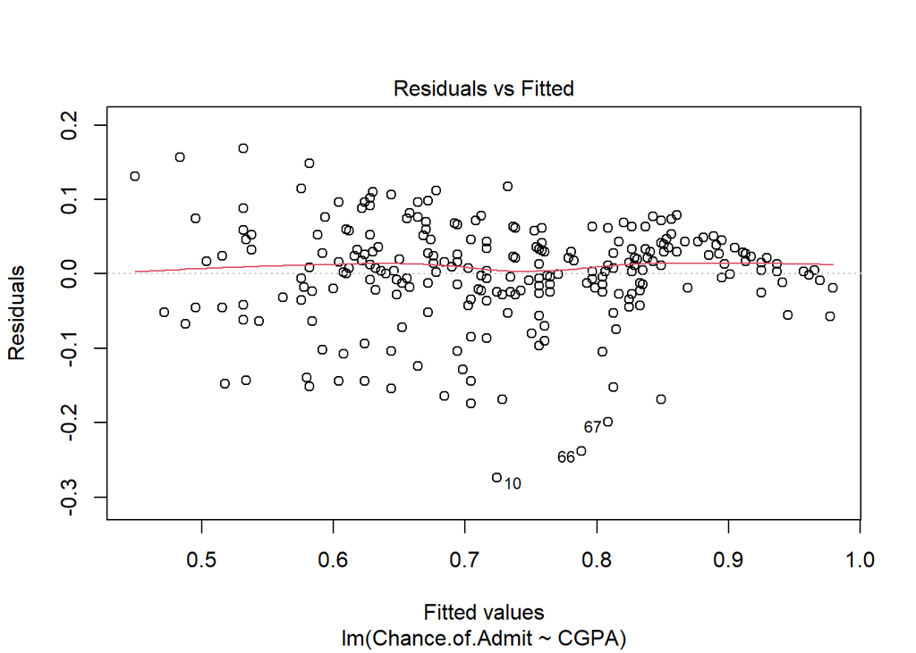

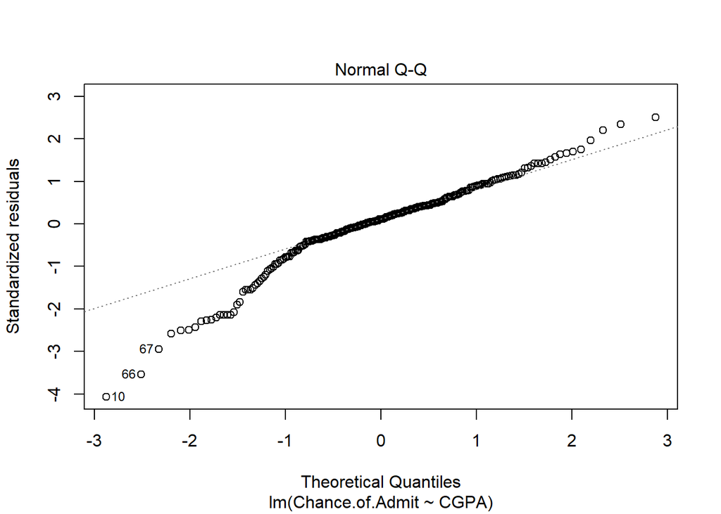

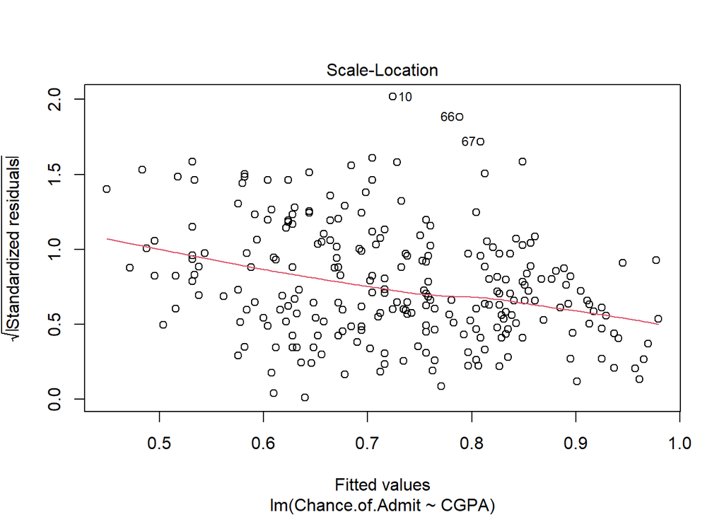

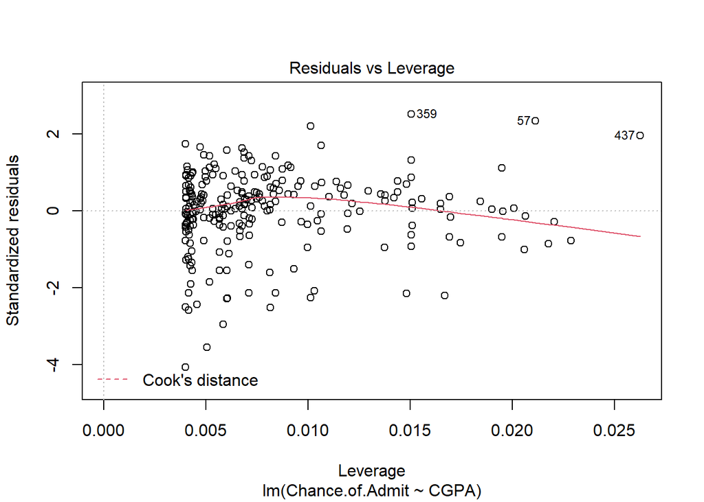

```r
lm.single <- lm(Chance.of.Admit ~ CGPA, data = train_set)
plot(lm.single)
```

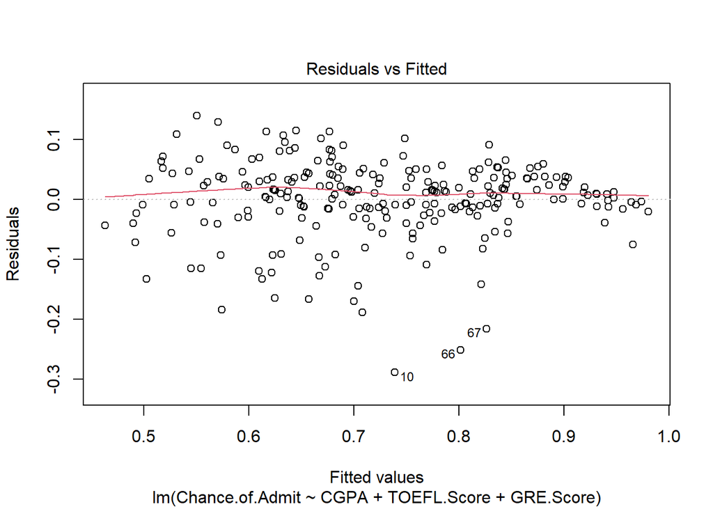

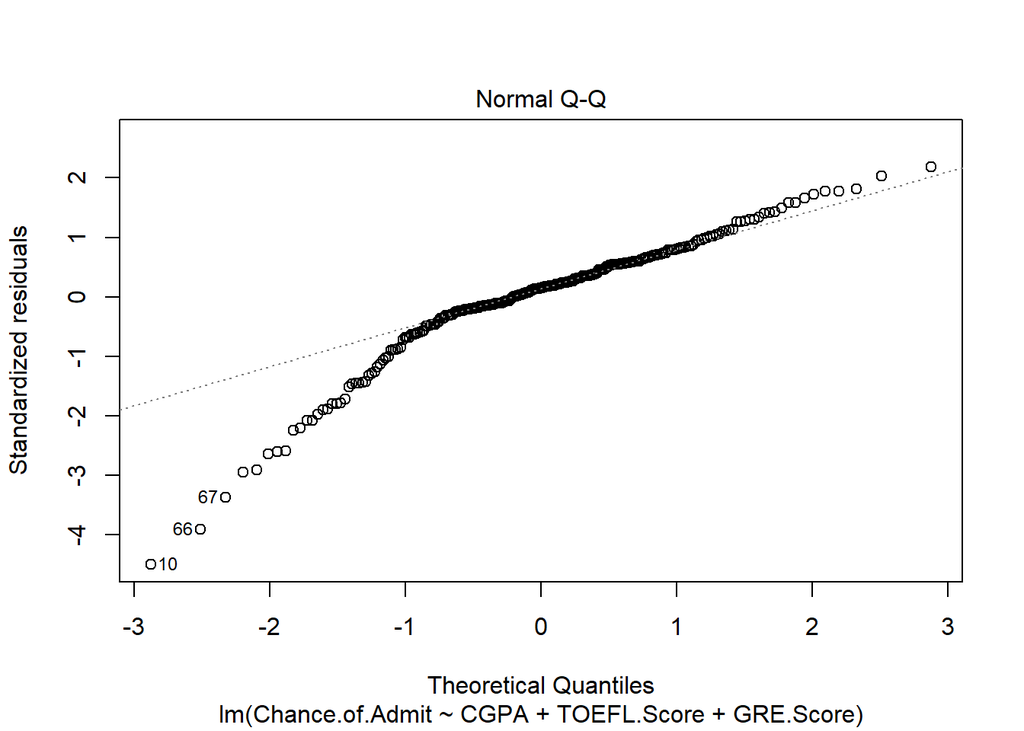

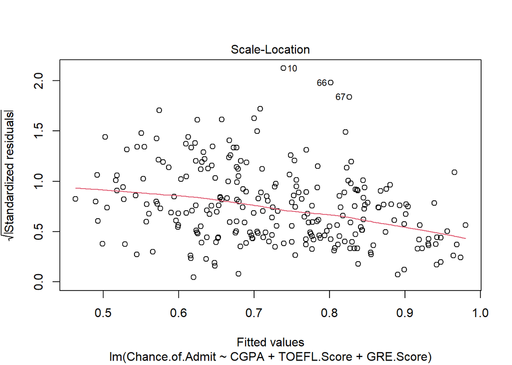

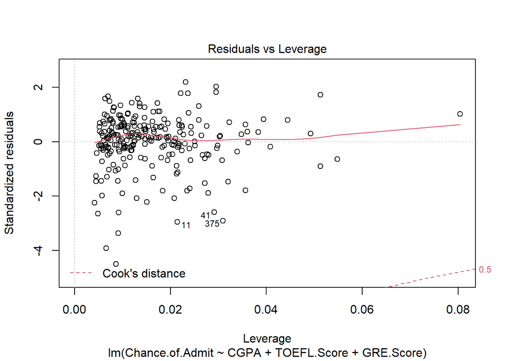

```r
lm.multi <- lm(Chance.of.Admit ~ CGPA + TOEFL.Score + GRE.Score, data = train_set)
plot(lm.multi)
```

*3.Finally, we fit a model that use all predictors*

```r
lm.full <- lm(Chance.of.Admit ~ ., data = train_set)
```

```r
# calculate the rmse and r2 of each model
model_single_rmse <- RMSE(lm.single$fitted.values, obs = train_set$Chance.of.Admit)
model_multi_rmse <- RMSE(lm.multi$fitted.values, obs = train_set$Chance.of.Admit)
model_full_rmse <- RMSE(lm.full$fitted.values, obs = train_set$Chance.of.Admit)
model_rmse_table <- data.frame(model_single_rmse, model_multi_rmse, model_full_rmse)
model_rmse_table
```

| model_single_rmse | model_multi_rmse | model_full_rmse |
| --- | --- | --- |
| 0.06725626 | 0.06389401 | 0.06059738 |

```r
# calculate the rsq value of trained model
model_single_rsq <- cor(lm.single$fitted.values, train_set$Chance.of.Admit)^2
model_multi_rsq <- cor(lm.multi$fitted.values, train_set$Chance.of.Admit)^2
model_full_rsq <- cor(lm.full$fitted.values, train_set$Chance.of.Admit)^2
model_rsq_table <- data.frame(model_single_rsq, model_multi_rsq, model_full_rsq)
model_rsq_table
```

| model_single_rsq | model_multi_rsq | model_full_rsq |
| --- | --- | --- |
| 0.7555103 | 0.7793442 | 0.8015264 |

```r
# we can also use screenreg to show imformation about our model and choose the optimal one
screenreg(list(lm.single, lm.multi, lm.full))
```

```
##
## =====================================================
##                    Model 1     Model 2     Model 3
## -----------------------------------------------------
## (Intercept)         -1.00 ***   -1.52 ***   -1.18 ***
##                     (0.06)      (0.13)      (0.15)
## CGPA                 0.20 ***    0.15 ***    0.11 ***
##                     (0.01)      (0.01)      (0.01)
## TOEFL.Score                      0.00 *      0.00
##                                 (0.00)      (0.00)
## GRE.Score                        0.00 **     0.00 **
##                                 (0.00)      (0.00)
## University.Rating                            0.01
##                                             (0.01)
## SOP                                          0.01
##                                             (0.01)
## LOR                                          0.02 **
##                                             (0.01)
## Research                                     0.02
##                                             (0.01)
## -----------------------------------------------------
## R^2                  0.76        0.78        0.80
## Adj. R^2             0.75        0.78        0.80
## Num. obs.          250         250         250
## =====================================================
## *** p < 0.001; ** p < 0.01; * p < 0.05
```

# 6 Cross Validation

We use 10-fold cross validation method.k-fold cross-validation method evaluates the model performance on different subset of the training data and then calculate the average prediction error rate

```r
# First we Define training control,
set.seed(2)
train.control <- trainControl(method = "cv", number = 10)
# Train the model
cv.lm.full <- train(Chance.of.Admit ~ ., data = train_set, method = "lm",
               trControl = train.control)
# Summarize the results
print(cv.lm.full)
```

```
## Linear Regression
##
## 250 samples
##   7 predictor
##
## No pre-processing
## Resampling: Cross-Validated (10 fold)
## Summary of sample sizes: 225, 225, 225, 225, 226, 223, ...
## Resampling results:
##
##   RMSE        Rsquared   MAE
##   0.06187379  0.8143748  0.04521587
##
## Tuning parameter 'intercept' was held constant at a value of TRUE
```

# 7 Evaluation

After choosing the model with the best performance measure, we can make predictions using our trained model and store in the test dataset

prediction evaluation result using all predictor model lm.full:

```r
# making prediction
test_set$full_model_output <- predict(lm.full, newdata = test_set)
```

*Calculate the RMSE and R2 value of our testset*

```r
# calculate the RMSE on the test dataset
testset_rmse <- RMSE(test_set$full_model_output, obs = test_set$Chance.of.Admit)
testset_rmse
```

```
## [1] 0.05946952
```

*Calculate the RMSE and R2 value of our test data set*

```r
# calculate the R2 value on the test dataset
testset_rsq <- cor(test_set$full_model_output, test_set$Chance.of.Admit)^2
testset_rsq
```

```
## [1] 0.8350148
```

# 8 Conclusion

We have already learn how to build a linear regression model and what need to be concerned when building the model.